# Projeto final

Bem vindo ao projeto final do curso/módulo de Pandas. Neste projeto, você deve responder a um conjunto de perguntas feitas a dois conjuntos de dados:

1. [Obesity among adults by country, 1975-2016](https://www.kaggle.com/amanarora/obesity-among-adults-by-country-19752016/)
2. [GDP Per Person (1901-2011)](https://www.kaggle.com/divyansh22/gdp-per-person-19012011?select=GDP.csv)

Tais conjuntos de dados são públicos foram publicados no Kaggle. Mais instruções sobre cada um deles podem ser encontrados nos links acima. Você também os encontrará na pasta `data` , dentro de nossas apostilas.

```python
import pandas as pd
import numpy as np
import matplotlib.pyplot as plt
from warnings import filterwarnings

plt.style.use("default")
filterwarnings("ignore")
```

## Perguntas - Obesity among adults by country, 1975-2016

```python
df_obesity = pd.read_csv("data/obesity_cleaned.csv")
df_obesity.head()
```

|  | Unnamed: 0 | Country | Year | Obesity (%) | Sex |
| --- | --- | --- | --- | --- | --- |
| 0 | 0 | Afghanistan | 1975 | 0.5 [0.2-1.1] | Both sexes |
| 1 | 1 | Afghanistan | 1975 | 0.2 [0.0-0.6] | Male |
| 2 | 2 | Afghanistan | 1975 | 0.8 [0.2-2.0] | Female |
| 3 | 3 | Afghanistan | 1976 | 0.5 [0.2-1.1] | Both sexes |
| 4 | 4 | Afghanistan | 1976 | 0.2 [0.0-0.7] | Male |

- Limpe os dados do DataFrame, criando uma coluna de nome 'Obesity' que conterá os valores de obesidade. Transforme em float as colunas que porventura foram importadas como string.

```python
del df_obesity["Unnamed: 0"]
df_obesity["Obesity"] = df_obesity["Obesity (%)"].apply(lambda x: x.split(" ")[0])

df_obesity.loc[df_obesity["Obesity"] == "No", "Obesity"] = np.nan
df_obesity.dropna(inplace=True)
```

```python
df_obesity["Obesity"] = df_obesity["Obesity"].apply(lambda x: float(x))
# df_obesity["Obesity"] = df_obesity["Obesity"].astype(float)

df_obesity["Year"] = df_obesity["Year"].apply(lambda x: float(x))
df_obesity.set_index("Year", inplace=True)
```

- Qual o percentual médio de obesidade por sexo no mundo no ano de 2015?

```python
df_obesity[df_obesity.index == 2015].groupby("Sex")["Obesity"].mean()
```

```
Sex
Both sexes    19.508377
Female        22.899476
Male          15.980628
Name: Obesity, dtype: float64
```

- Quais são os 5 países com a maior e a menor taxa de aumento nos índices de obesidade no período observado?

```python
df_obesity_start = df_obesity[df_obesity.index == 1975]
df_obesity_end = df_obesity[df_obesity.index == 2016]

df_obesity_start.set_index("Country", inplace=True)
df_obesity_end.set_index("Country", inplace=True)
```

```python
df_obesity_ev = (
    df_obesity_end[df_obesity_end["Sex"] == "Both sexes"]["Obesity"]
    - df_obesity_start[df_obesity_start["Sex"] == "Both sexes"]["Obesity"]
)
```

```python
df_obesity_ev.sort_values().dropna().head(5)
```

```
Country
Viet Nam       2.0
Singapore      3.1
Japan          3.3
Bangladesh     3.4
Timor-Leste    3.6
Name: Obesity, dtype: float64
```

```python
df_obesity_ev.sort_values().dropna().tail(5)
```

```
Country
Cook Islands    27.9
Tonga           28.3
Kiribati        30.1
Niue            31.1
Tuvalu          33.7
Name: Obesity, dtype: float64
```

- Quais os países com maiores e menores níveis percetuais de obesidade em 2015?

```python
df_2015 = df_obesity[df_obesity.index == 2015].copy()
df_2015[df_2015["Obesity"] == df_2015["Obesity"].max()]
```

| Year | Country | Obesity (%) | Sex | Obesity |
| --- | --- | --- | --- | --- |
| 2015.0 | Nauru | 63.1 [55.5-70.3] | Female | 63.1 |

```python
df_2015 = df_obesity[df_obesity.index == 2015].copy()
df_2015[df_2015["Obesity"] == df_2015["Obesity"].min()]
```

| Year | Country | Obesity (%) | Sex | Obesity |
| --- | --- | --- | --- | --- |
| 2015.0 | Viet Nam | 1.5 [0.8-2.5] | Male | 1.5 |

- Qual a diferença média percentual de obesidade entre sexos ao longo dos anos para o Brasil?

```python
df_brasil = df_obesity[df_obesity["Country"] == "Brazil"]
```

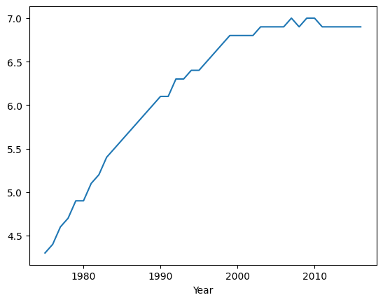

```python
(
    df_brasil[df_brasil["Sex"] == "Female"]["Obesity"]
    - df_brasil[df_brasil["Sex"] == "Male"]["Obesity"]
).plot()
```

### Análise da diferença média percentual

O gráfico mostra a diferença percentual de obesidade entre mulheres e homens no Brasil ao longo dos anos. Observa-se que, consistentemente, a obesidade é maior entre as mulheres do que entre os homens. A diferença se mantém positiva durante todo o período analisado, com pequenas variações, mas sem inversão. Em geral, a tendência é de aumento dessa diferença até meados dos anos 2000, seguida de uma leve estabilização ou redução nos anos mais recentes. Isso indica que, apesar do crescimento da obesidade em ambos os sexos, o avanço foi mais expressivo entre as mulheres brasileiras.

- Você conseguiria plotar um gráfico mostrando a evolução da obesidade para ambos sexos no mundo?

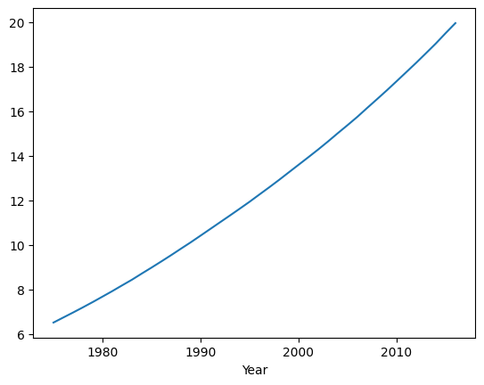

```python
all_countries = df_obesity["Country"].value_counts()
df_both = df_obesity[df_obesity["Sex"] == "Both sexes"]
df_both = df_both.groupby("Year")["Obesity"].mean()
df_both.plot()
```

### Evolução da obesidade para ambos os sexos no mundo

O gráfico apresenta a evolução média da obesidade mundial entre adultos ao longo dos anos, considerando ambos os sexos. Observa-se uma tendência clara de aumento contínuo nos índices de obesidade globalmente, sem períodos de queda significativa. O crescimento é relativamente constante, indicando que a obesidade vem se tornando um problema cada vez mais prevalente em escala mundial durante o período analisado.

## Perguntas - GDP Per Person (1901-2011)

```python
df_gdp = pd.read_csv("data/GDP.csv", decimal=".")
```

```python
df_gdp.columns
```

```
Index(['Country', 'Region', 'Year', ' GDP_pp '], dtype='object')
```

- Limpe o conjunto de dados, convertendo strings em datas ou float, quando necessário.

```python
df_gdp["Year"] = df_gdp["Year"].apply(lambda x: int(x.split("/")[-1]))
```

```python
df_gdp["gdp_pp"] = df_gdp[" GDP_pp "].apply(
    lambda x: float(x.split(" ")[1].replace(",", ""))
)
del df_gdp[" GDP_pp "]
```

```python
df_gdp.head(3)
```

|  | Country | Region | Year | gdp_pp |
| --- | --- | --- | --- | --- |
| 0 | Afghanistan | Middle East, North Africa, and Greater Arabia | 1901 | 613.99 |
| 1 | Afghanistan | Middle East, North Africa, and Greater Arabia | 1906 | 624.04 |
| 2 | Afghanistan | Middle East, North Africa, and Greater Arabia | 1911 | 634.25 |

- Você conseguiria informar o primeiro valor registrado de cada país?

```python
df_gdp.groupby("Country").min()["Year"]
```

```
Country
Afghanistan    1901
Albania        1901
Algeria        1901
Andorra        1901
Angola         1901
               ...
Venezuela      1901
Vietnam        1901
Yemen, Rep.    1901
Zambia         1901
Zimbabwe       1901
Name: Year, Length: 193, dtype: int64
```

```python
df_gdp.groupby("Country").min()["Year"].isna().sum()
```

```
0
```

```python
df_gdp.groupby("Country").min()["Year"].value_counts()
```

```
Year
1901    192
1991      1
Name: count, dtype: int64
```

```python
df_gdp.groupby("Country").min()["Year"][df_gdp.groupby("Country").min()["Year"] == 1991]
```

```
Country
Kosovo    1991
Name: Year, dtype: int64
```

- Informe as regiões com maiores crescimentos de PIB per capita no século passado.

```python
df_gdp[df_gdp["Year"] < 2000]["Year"].max()
```

```
1996
```

```python
df_gdp_start = df_gdp[(df_gdp["Year"] == 1901)]
df_gdp_end = df_gdp[(df_gdp["Year"] == 1996)]
```

```python
(
    (
        df_gdp_end.groupby("Region")["gdp_pp"].mean()
        / df_gdp_start.groupby("Region")["gdp_pp"].mean()
        - 1
    )
    * 100
).sort_values(ascending=False)
```

```
Region
Middle East, North Africa, and Greater Arabia    857.215950
Asia                                             711.761516
Europe                                           594.046167
North America                                    589.760175
Central America and the Caribbean                406.426789
Australia and Oceania                            396.075383
South America                                    312.123735
Sub-Saharan Africa                               248.633780
Name: gdp_pp, dtype: float64
```

- Preecha os anos ausentes em cada país com uma estimativa, baseada na diferença entre o próximo registro e o anterior.

```python
df_gdp.head()
```

|  | Country | Region | Year | gdp_pp |
| --- | --- | --- | --- | --- |
| 0 | Afghanistan | Middle East, North Africa, and Greater Arabia | 1901 | 613.99 |
| 1 | Afghanistan | Middle East, North Africa, and Greater Arabia | 1906 | 624.04 |
| 2 | Afghanistan | Middle East, North Africa, and Greater Arabia | 1911 | 634.25 |
| 3 | Afghanistan | Middle East, North Africa, and Greater Arabia | 1916 | 647.28 |
| 4 | Afghanistan | Middle East, North Africa, and Greater Arabia | 1921 | 662.40 |

```python
arr_years = np.arange(df_gdp["Year"].min(), df_gdp["Year"].max())
df_all_years = pd.DataFrame(arr_years, columns=["Year"])
df_all_years.index = df_all_years["Year"]

df_years_off = ~df_all_years["Year"].isin(df_gdp["Year"])
df_years_off = df_years_off[df_years_off].index
```

```python
df_gdp = df_gdp.sort_values(["Country", "Year"])

df_gdp["delta_gdp"] = df_gdp["gdp_pp"] - df_gdp["gdp_pp"].shift(1)
df_gdp["delta_year"] = df_gdp["Year"] - df_gdp["Year"].shift(1)
df_gdp["gdp_year"] = (df_gdp["delta_gdp"] / df_gdp["delta_year"]).shift(-1)
```

```python
df_gdp["next_year"] = df_gdp["Year"].shift(-1)
del df_gdp["delta_gdp"], df_gdp["delta_year"]
```

```python
df_new_data = pd.DataFrame()

for idx, row in df_gdp.iterrows():
    if row["Year"] == 2011:
        continue

    # print(idx, row)
    year_to_add = df_years_off[
        (df_years_off < row["next_year"]) & (df_years_off > row["Year"])
    ]

    for new_year in year_to_add:
        add_row = row.copy()
        add_row["gdp_pp"] = (new_year - add_row["Year"]) * add_row[
            "gdp_year"
        ] + add_row["gdp_pp"]
        add_row["Year"] = new_year
        df_new_data["kind"] = "estimated"
        df_new_data = pd.concat([df_new_data, add_row.to_frame().transpose()])
```

```python
df_gdp.iloc[100:].head(10)
```

|  | Country | Region | Year | gdp_pp | gdp_year | next_year |
| --- | --- | --- | --- | --- | --- | --- |
| 100 | Angola | Sub-Saharan Africa | 1941 | 2170.80 | 119.530 | 1946.0 |
| 101 | Angola | Sub-Saharan Africa | 1946 | 2768.45 | 134.490 | 1951.0 |
| 102 | Angola | Sub-Saharan Africa | 1951 | 3440.90 | 21.628 | 1956.0 |
| 103 | Angola | Sub-Saharan Africa | 1956 | 3549.04 | 182.958 | 1961.0 |
| 104 | Angola | Sub-Saharan Africa | 1961 | 4463.83 | 168.862 | 1966.0 |
| 105 | Angola | Sub-Saharan Africa | 1966 | 5308.14 | 43.614 | 1971.0 |
| 106 | Angola | Sub-Saharan Africa | 1971 | 5526.21 | -495.178 | 1976.0 |
| 107 | Angola | Sub-Saharan Africa | 1976 | 3050.32 | -19.382 | 1981.0 |
| 108 | Angola | Sub-Saharan Africa | 1981 | 2953.41 | -146.560 | 1986.0 |
| 109 | Angola | Sub-Saharan Africa | 1986 | 2220.61 | 102.048 | 1991.0 |

```python
df_gdp = pd.concat([df_gdp, df_new_data]).sort_values(["Country", "Year"])
df_gdp["kind"].fillna("real", inplace=True)
df_gdp.index = df_gdp["Year"]
```

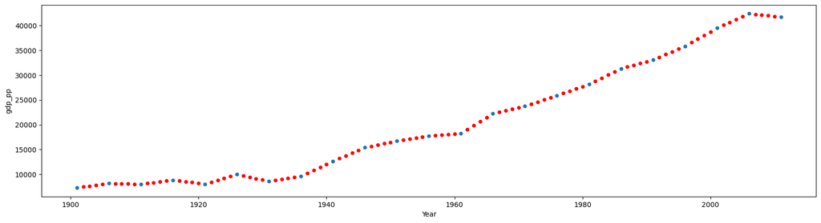

```python
fig, ax = plt.subplots(figsize=(20, 5))
df_gdp[(df_gdp["kind"] == "real") & (df_gdp["Country"] == "United States")].plot(
    kind="scatter", y="gdp_pp", x="Year", ax=ax
)
df_gdp[(df_gdp["kind"] == "estimated") & (df_gdp["Country"] == "United States")].plot(
    kind="scatter", y="gdp_pp", x="Year", ax=ax, color="red"
)
```

### DESAFIOS

- Você conseguiria criar um mapa do gdp ou da obesidade no mundo ao longo dos anos?

```python
df_gdp[df_gdp["kind"] == "real"].reset_index(drop=True).head(5)
```

|  | Country | Region | Year | gdp_pp | gdp_year | next_year | kind |
| --- | --- | --- | --- | --- | --- | --- | --- |
| 0 | Afghanistan | Middle East, North Africa, and Greater Arabia | 1901 | 613.99 | 2.01 | 1906.0 | real |
| 1 | Afghanistan | Middle East, North Africa, and Greater Arabia | 1906 | 624.04 | 2.042 | 1911.0 | real |
| 2 | Afghanistan | Middle East, North Africa, and Greater Arabia | 1911 | 634.25 | 2.606 | 1916.0 | real |
| 3 | Afghanistan | Middle East, North Africa, and Greater Arabia | 1916 | 647.28 | 3.024 | 1921.0 | real |
| 4 | Afghanistan | Middle East, North Africa, and Greater Arabia | 1921 | 662.4 | 3.094 | 1926.0 | real |

```python
df_gdp["Year"] = df_gdp["Year"].astype(int)
df_gdp["gdp_pp"] = df_gdp["gdp_pp"].astype(float)
```

```python
import plotly.express as px

df = px.data.gapminder()
dict_iso_alpha = df.set_index("country").to_dict()["iso_alpha"]
dict_num = {j: i for i, j in enumerate(df_gdp["Country"].unique())}

df_gdp["iso_alpha"] = df_gdp["Country"].map(dict_iso_alpha)
df_gdp["iso_num"] = df_gdp["Country"].map(dict_num)

fig = px.choropleth(
    df_gdp[df_gdp["kind"] == "real"].reset_index(drop=True),
    locations="iso_alpha",
    color="gdp_pp",
    hover_name="Country",
    animation_frame="Year",
)

fig.update_layout(height=600)
fig.show()
```

- Há uma relação entre níveis de obesidade e gdp per capita?

```python
df_obesity["country-year"] = (
    df_obesity["Country"]
    + "-"
    + df_obesity.reset_index()["Year"].apply(lambda x: str(int(x))).values
)
dict_obesity_year = df_obesity.set_index("country-year").to_dict()["Obesity"]
```

```python
df_gdp["country-year"] = (
    df_gdp["Country"] + "-" + df_gdp["Year"].apply(lambda x: str(x)).values
)
df_gdp["Obesity"] = df_gdp["country-year"].map(dict_obesity_year)
```

```python
df_gdp_clean = df_gdp.dropna()
```

```python
countries = df_gdp_clean["Country"].unique()
```

```python
corr_list = []
for country in countries:
    corr_list += [
        df_gdp_clean[df_gdp_clean["Country"] == country][["Obesity", "gdp_pp"]]
        .corr()
        .iloc[0, 1]
    ]

df_corr = pd.Series(corr_list, index=countries)
```

```python
df_corr.mean()
```

```
0.5156020945367675
```

```python
df_corr.std()
```

```
0.6523066623226487
```

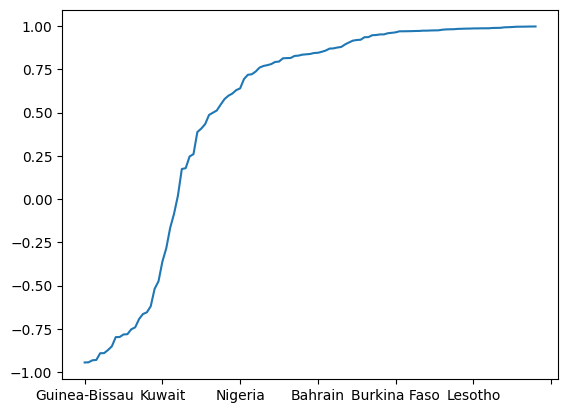

```python
df_corr.sort_values().plot()
```

### Relação entre níveis de obesidade e PIB per capita

O gráfico exibe a distribuição dos coeficientes de correlação entre obesidade e PIB per capita para diferentes países. Observa-se que a maioria dos países apresenta correlação positiva, indicando que, em geral, quanto maior o PIB per capita, maior tende a ser o nível de obesidade. No entanto, há variação significativa entre os países, com alguns apresentando correlação negativa ou próxima de zero, sugerindo que a relação entre riqueza e obesidade não é uniforme globalmente.

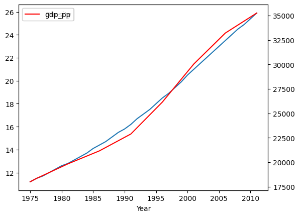

```python
country = "Australia"
fig, ax = plt.subplots()
df_gdp_clean[df_gdp_clean["Country"] == country][["Obesity"]].plot(ax=ax)
ax2 = ax.twinx()
df_gdp_clean[df_gdp_clean["Country"] == country][["gdp_pp"]].plot(ax=ax2, color="red")
```

### Relação entre níveis de obesidade e PIB per capita na Austrália

O gráfico apresenta, para a Austrália, a evolução dos níveis de obesidade (em azul) e do PIB per capita (em vermelho) ao longo dos anos. Observa-se que ambos os indicadores apresentam tendência de crescimento contínuo no período analisado. O aumento do PIB per capita acompanha, em geral, o crescimento dos índices de obesidade, sugerindo uma relação positiva entre prosperidade econômica e elevação dos níveis de obesidade no país. Não há quedas prolongadas em nenhum dos indicadores, apenas pequenas variações pontuais.

```python
df_gdp_clean
```

| Year | Country | Region | Year | gdp_pp | gdp_year | next_year | kind | iso_alpha | iso_num | country-year | Obesity |
| --- | --- | --- | --- | --- | --- | --- | --- | --- | --- | --- | --- |
| 1975 | Afghanistan | Middle East, North Africa, and Greater Arabia | 1975 | 847.692 | 18.498 | 1976.0 | estimated | AFG | 0 | Afghanistan-1975 | 0.8 |
| 1976 | Afghanistan | Middle East, North Africa, and Greater Arabia | 1976 | 866.190 | 6.134 | 1981.0 | real | AFG | 0 | Afghanistan-1976 | 0.8 |
| 1977 | Afghanistan | Middle East, North Africa, and Greater Arabia | 1977 | 872.324 | 6.134 | 1981.0 | estimated | AFG | 0 | Afghanistan-1977 | 0.9 |
| 1978 | Afghanistan | Middle East, North Africa, and Greater Arabia | 1978 | 878.458 | 6.134 | 1981.0 | estimated | AFG | 0 | Afghanistan-1978 | 0.9 |
| 1979 | Afghanistan | Middle East, North Africa, and Greater Arabia | 1979 | 884.592 | 6.134 | 1981.0 | estimated | AFG | 0 | Afghanistan-1979 | 1.0 |
| ... | ... | ... | ... | ... | ... | ... | ... | ... | ... | ... | ... |
| 2006 | Zimbabwe | Sub-Saharan Africa | 2006 | 520.170 | 1.232 | 2011.0 | real | ZWE | 192 | Zimbabwe-2006 | 20.9 |
| 2007 | Zimbabwe | Sub-Saharan Africa | 2007 | 521.402 | 1.232 | 2011.0 | estimated | ZWE | 192 | Zimbabwe-2007 | 21.3 |
| 2008 | Zimbabwe | Sub-Saharan Africa | 2008 | 522.634 | 1.232 | 2011.0 | estimated | ZWE | 192 | Zimbabwe-2008 | 21.7 |
| 2009 | Zimbabwe | Sub-Saharan Africa | 2009 | 523.866 | 1.232 | 2011.0 | estimated | ZWE | 192 | Zimbabwe-2009 | 22.2 |
| 2010 | Zimbabwe | Sub-Saharan Africa | 2010 | 525.098 | 1.232 | 2011.0 | real | ZWE | 192 | Zimbabwe-2010 | 22.6 |

4328 rows × 11 columns

```python
df_gdp_clean.reset_index(drop=True).groupby("Year")[
    ["Obesity", "gdp_pp"]
].mean().corr().iloc[0, 1]
```

```
0.9693775432125091
```